# Individual Assignment #3

### Regression with ARIMA Errors Laboratory.

#### (Total 40 pts.)

#### Due: Dec. 2 (before midnight)

As a newly minted MSBA you start working for a large resort hotel managing 1,877 rooms. A tour operator that you frequently do business with has requested a block of 60 rooms for Aug. 22. As this operator will pay a discounted rate for each room, your manager is uncertain if she should give this block of rooms to the tour operator, and she has asked you to provide model-based support for this decision.

Although the price is discounted and it may prevent you from selling some of these rooms at the regular price, if you reject this request, any empty rooms will not generate any revenue and you would have incurred an opportunity cost by not selling these rooms.

After judicious consideration of the economic trade offs in the News vendor model, you and your manager determine that the block should be assigned to the tour operator only if the probability of your organic demand (excluding the room block in question) is smaller than 67% (i.e., you are on track to achieve a 67% service level).

To address the booking question you examine the following data set and proceed to develop a demand forecast model.

The code below reads the data set which includes up to the latest demand information (August 17) and prepares the data for the modeling process:

```r
library(fpp3)
library(tseries)
X <- read.csv("Booking Exercise.csv") %>%
  mutate(DATE = ymd(DATE)) %>%
  as_tsibble(index = DATE)


Fcst.X <- X %>% filter(DATE >= ymd("2010-08-18")) #forecastable data
X <- X %>% filter(DATE <= ymd("2010-08-17")) #historic data
```

1. (15 pt.) Fit (a) an ETS, (b) a plain ARIMA, (c) a linear regression model to predict **DEMAND** as a function of **TUESDAY.BOOK**, (c) a non-seasonal regression model with ARIMA errors using **TUESDAY.BOOK** and **DOW.INDEX** as explanatory variables, and (d) a seasonal regression model with ARIMA errors using only **TUESDAY.BOOK** as an explanatory variable. You may use automatic model selection to fit an initial model, but especially in cases (c) and (d) you should modify the automatically fitted models when appropriate.

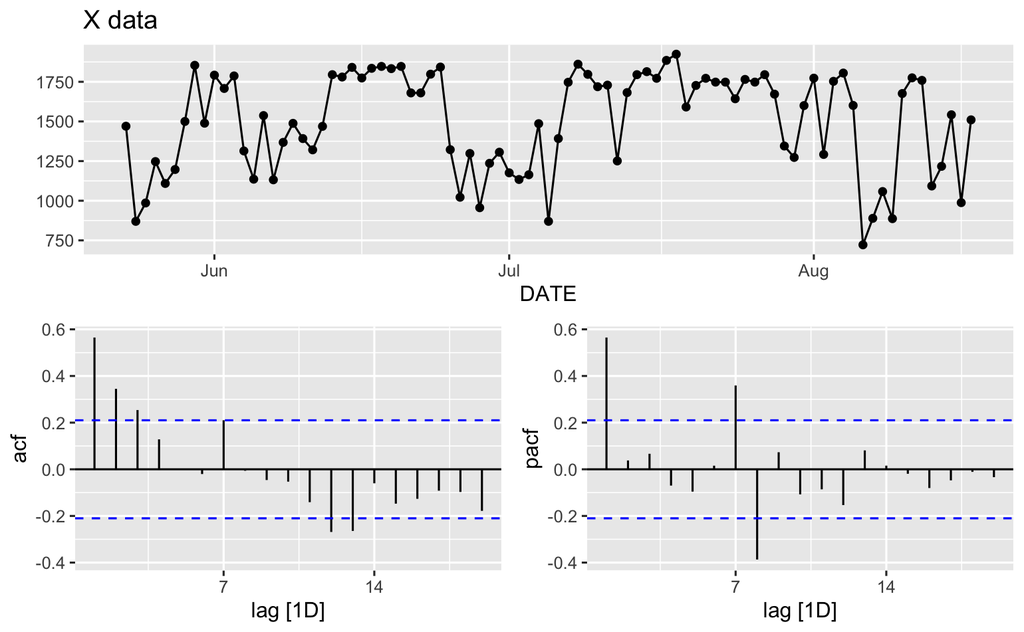

```r
#take a look at the data
X %>% gg_tsdisplay(DEMAND, plot_type = "partial") +
  labs(title="X data", y="")
```

```r
#differencing needed?
X %>% features(DEMAND, unitroot_nsdiffs) #seasonal differences needed = 0
```

| nsdiffs |
| --- |
| 0 |

```r
X %>% features(DEMAND,unitroot_ndiffs) #differences needed = 0
```

| ndiffs |
| --- |
| 0 |

```r
m <- X %>%
  model(auto.ETS = ETS(DEMAND),
        auto.ARIMA = ARIMA(DEMAND),
        lr = TSLM(DEMAND ~ TUESDAY.BOOK), #LR
        lr.ARIMA = ARIMA(DEMAND ~ TUESDAY.BOOK), #non-seasonal LR with ARIMA errors
        lr.ARIMA.seasonal = ARIMA(DEMAND ~ TUESDAY.BOOK + PDQ(2,0,0))) #seasonal LR w/ ARIMA errors
```

```r
m %>% augment() %>%
  features(.resid, ljung_box, lag = 60)
```

| .model | lb_stat | lb_pvalue |
| --- | --- | --- |
| auto.ARIMA | 44.91846 | 0.9265256 |
| auto.ETS | 72.68825 | 0.1260378 |
| lr | 275.26421 | 0.0000000 |
| lr.ARIMA | 70.20316 | 0.1727387 |
| lr.ARIMA.seasonal | 60.60016 | 0.4540399 |

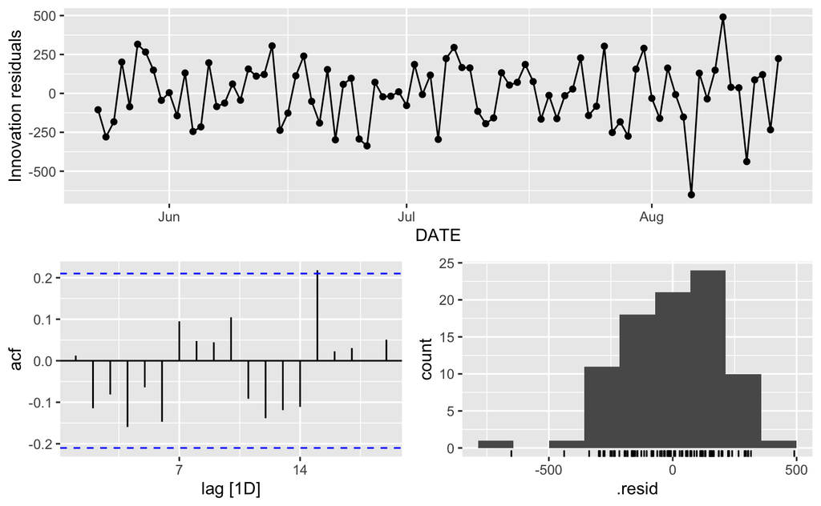

```r
m %>% select(auto.ETS) %>% gg_tsresiduals()
```

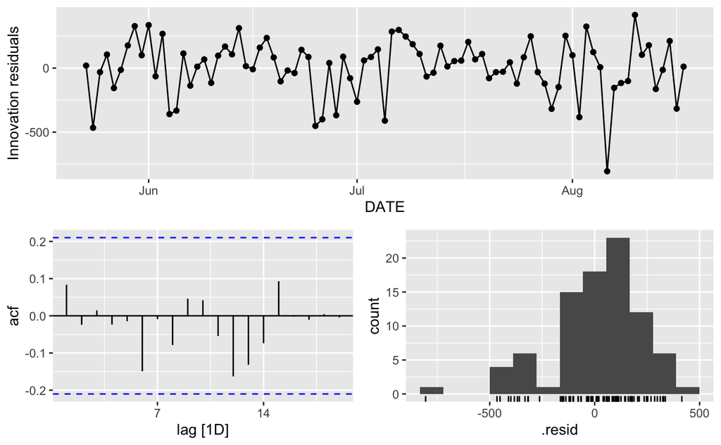

```r
m %>% select(auto.ARIMA) %>% gg_tsresiduals()
```

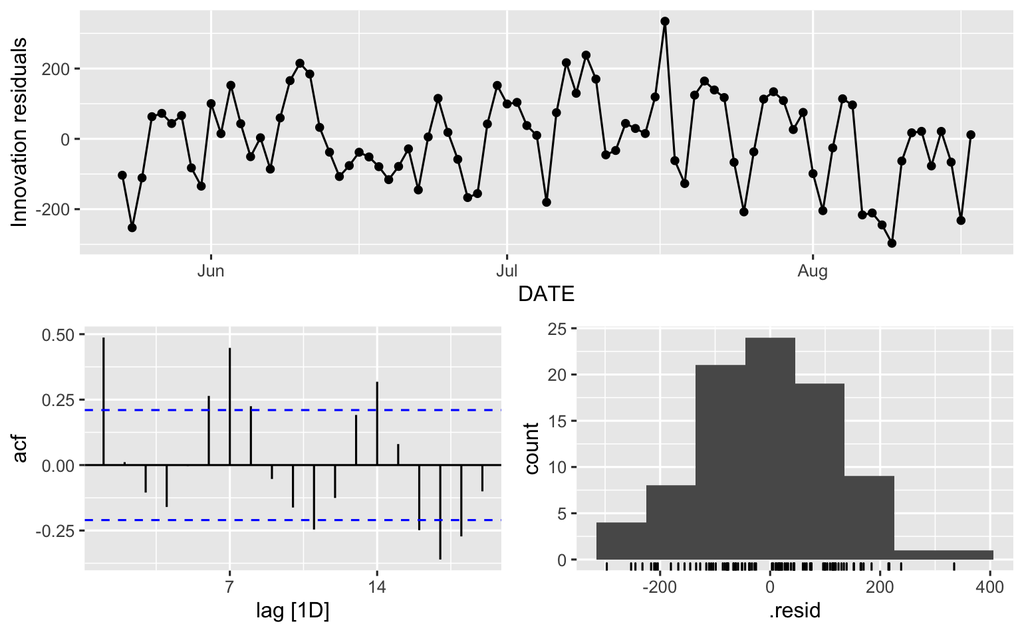

```r
m %>% select(lr) %>% gg_tsresiduals()
```

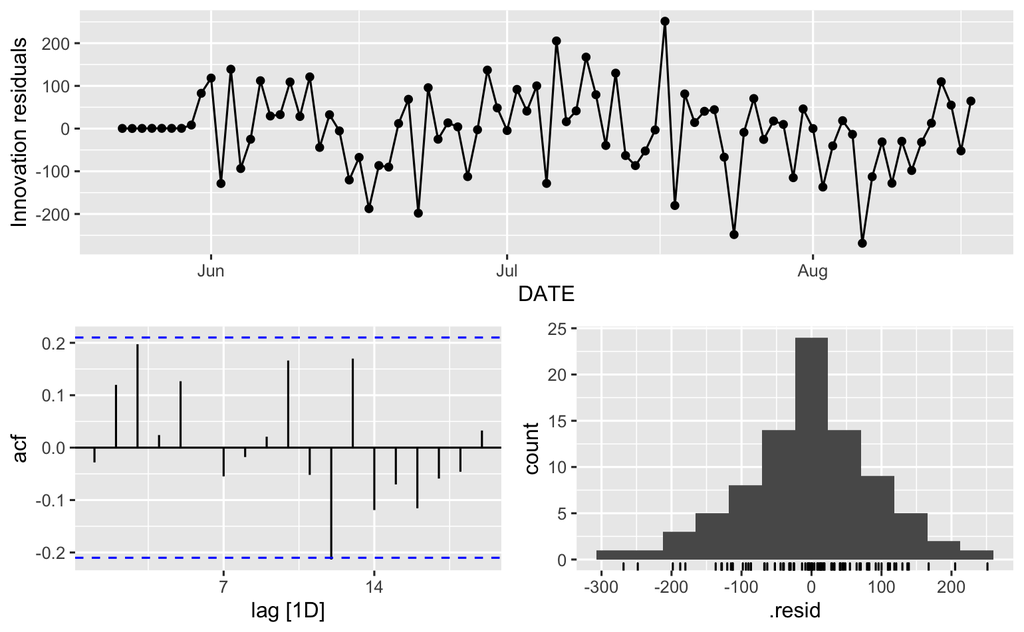

```r
m %>% select(lr.ARIMA) %>% gg_tsresiduals()
```

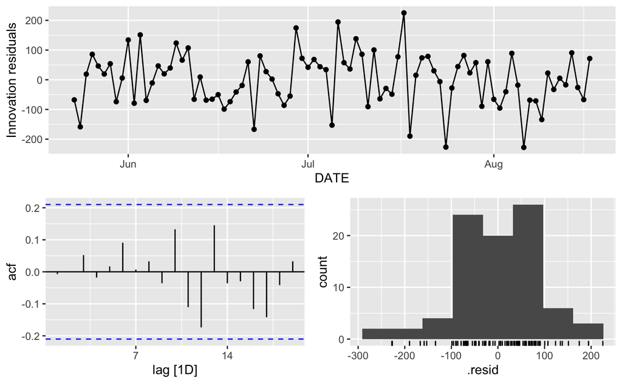

```r
m %>% select(lr.ARIMA.seasonal) %>% gg_tsresiduals()
```

3. (5 pt.) Using the information criteria (AICc and BIC) what is the best model?

| .model | AIC | AICc | BIC |
| --- | --- | --- | --- |
| auto.ETS | 1326.0105 | 1328.9053 | 1350.6696 |
| auto.ARIMA | 1195.0662 | 1195.8070 | 1207.3958 |
| lr | 846.6954 | 846.9846 | 854.0931 |
| lr.ARIMA | 973.1324 | 973.9432 | 985.0425 |
| lr.ARIMA.seasonal | 1047.6956 | 1049.5418 | 1067.4229 |

```r
fit <- m %>% select(lr.ARIMA)
forecast(fit, Fcst.X)
```

| .model | DATE | DEMAND | .mean | DOW | TUESDAY.BOOK | PICKUP.RATIO | DOW.INDEX |
| --- | --- | --- | --- | --- | --- | --- | --- |
| lr.ARIMA | 2010-08-18 |  | 1788.634 | 4 | 1657 | NA | 1.0125249 |
| lr.ARIMA | 2010-08-19 |  | 1731.059 | 5 | 1643 | NA | 1.0678813 |
| lr.ARIMA | 2010-08-20 |  | 1212.701 | 6 | 1124 | NA | 1.1227265 |
| lr.ARIMA | 2010-08-21 |  | 1233.015 | 7 | 1074 | NA | 1.0486263 |
| lr.ARIMA | 2010-08-22 |  | 1679.560 | 1 | 1839 | NA | 0.8647725 |
| lr.ARIMA | 2010-08-23 |  | 1586.003 | 2 | 1862 | NA | 0.9105852 |
| lr.ARIMA | 2010-08-24 |  | 1819.731 | 3 | 1886 | NA | 0.9728832 |

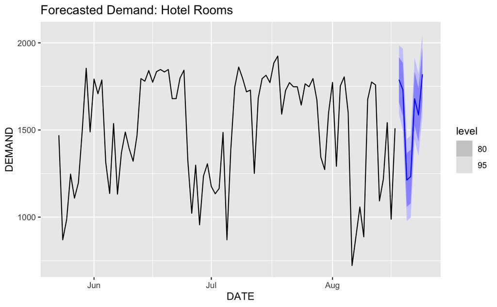

```r
forecast(fit, Fcst.X)  %>%
  autoplot(X) +
  labs(title="Forecasted Demand: Hotel Rooms")
```

5. (10 pt.) What is your recommendation for your manager regarding the tour operator block? Should your manager sell the block of 60 rooms at a discounted price? Justify your answer.

```r
1839/1877
```

```
[1] 0.9797549
```

Something to consider is the accuracy of our model, the forecasted demand for August 21st is much lower than August 22nd, so if we are even a day off on our forecast then we have potential lost out on additional revenue. While we would rent the rooms at a discounted rate, sometimes confirmed sales is better than projected sales that do not end up occuring.

With that being said, based on our best model chosen (lr.ARIMA) we would not book the block of 60 rooms because natural demand exceeds the set 67% service rate.